# Network analysis

Trude Almestrand

16 10 2020

# Assignment 6

## QOTW

*1. Given unlimited computational resources, how would you infer a Bayesian network from a gene expression table? Explain. Write approximately 250 words.*

Using Bayes we assume that the causal structure satisfies the Causal Markov Assumption (each node depends only on its parent nodes). Further on a Bayesian Networks consists of two components: A network structure in the form of a directed acyclig graph (DAG). And a set of conditional probability distributions one for each variable (specified by network parameters).

In order to infer a Bayesian network I would first sort the signifant data into either up or down-regulated in order to have two conditions to separate the data from. Log fold change positive = upregulated, log fold change negative = downregulated. Seeing as I have unlimited computational resources I would run the Bayesian algorithm (Bayes theorem) for all possible networks, not worried about computational time, then choosing the most probable network given the data.

The result we get will be a network consisting of similar expression level for genes.

*2. A plant biologist is worried about how rising CO2 levels affect wheat production, and has therefore studied grain development at two different CO2 levels; A and B. He generated two transcriptomics datasets where gene expression is quantified across samples taken from multiple tissues and at different times using RNA-Seq. He then used these two datasets to infer two co-expression networks that describe expression similarities in conditions A and B, respectively. Looking at the networks he realizes that these are gigantic hairballs with thousands of nodes connected by millions of links. Hence it is not easy to identify the differences in co-expression between condition A and B. The biologist therefore comes to you. How would you analyze the data? Describe the method you would use and what type of results you would get by applying this method. Write approximately 250 words.*

Infer a network for each level. Construct differential network and matrix. Use hierarcical clustering to find altered clusters in the differential matrix. What the results may show is a difference in gene networking between the two levels. Do genes lose or gain importance when compared to different CO2 levels. With this he can detect genes that gain or lose in expression levels and also the genes that stay the same.

He can perform a weighted co-expression analysis. Using this he can identify clusters of genes for further analysis instead of the many thousands he has found in his analysis. He can perform this the same way that has been done in this computer lab. First he can perform a rough clustering of both datasets separately in order to reduce computational time. Then contine on with the analysis by computing the correlation between modules, and within. This is a way to sort the data first of all, he does not want genes that do not correlate within the module. What he can then do is compare these two datasets by running a simple t test for his modules and then choosing the most significant ones for further analysis (meaning they are the most different). Then he can compute the pearson correlation between each gene expression and module (by the ones most significant in both datasets). He can then sort both datasets and see if there is a difference in the result between the two datasets. Which genes are the most central in each module? If there are different central genes it may show the answer he was looking for. Although I have not taken into account that clustering may not be the same, so perhaps it would be wise to merge them together with condition being the CO2 value and run this test as one dataset instead.

## Computer lab

Weighted gene co-expression network analysis (WGCNA) is an R package, but also a method used to analyze expression data. In short, the principle behind this method is to infer a co-expression network which then is used to identify modules, i.e. clusters of genes, which can then be used for further analysis instead of tens of thousands of individual genes. In this lab we will try to reproduce the results achieved using the WGCNA in the Voineagu et al autistic brain study.

```r
library(WGCNA)
library(beadarray)
```

```r
library(ggplot2)
load(file= "voineagu_normalized_microarray.RData")
```

The blockwiseModules function first performs a rough clustering of the genes into manageable blocks before network construction and module detection is performed for each block. Dividing the data into blocks like this reduces the computation time and memory requirement significantly, but it may still take some minutes to complete. The parameters are set according to the method description in the article:

```r
exp <- t(exprs(bsd.cortex.norm))  # transpose the expression matrix to get samples in rows and genes in columns
modules <- blockwiseModules(datExpr = exp, power = 10, minModuleSize = 40, minAbsSplitHeight = 0.1)
```

*What the different blockwiseModule does* blockwiseModule power:  
soft-thresholding power for network construction. Assumption is that by raising the correlation to a power will redce the noise of the correlations in the adhacency matrix. The power determines the correlation between the other genes to assess how much two genes are correlated.

blockwisemodule minModuleSize: minimum module size for module detection, has to contain at least 40 genes.

BlockwiseModules networkType(“unsigned”), meaning the sign of the correlation does not matter. We want both negative and positive correlation.

```r
str(modules)
```

```
## List of 10
##  $ colors        : Named chr [1:12353] "grey" "purple" "purple" "yellow" ...
##   ..- attr(*, "names")= chr [1:12353] "ILMN_1660305" "ILMN_1814316" "ILMN_2359168" "ILMN_1731507" ...
##  $ unmergedColors: Named chr [1:12353] "grey" "darkred" "darkred" "green" ...
##   ..- attr(*, "names")= chr [1:12353] "ILMN_1660305" "ILMN_1814316" "ILMN_2359168" "ILMN_1731507" ...
##  $ MEs           :'data.frame':  58 obs. of  23 variables:
##   ..$ MEcyan        : num [1:58] 0.1481 0.0854 -0.0539 0.0942 0.0181 ...
##   ..$ MEblue        : num [1:58] 0.1504 0.1498 -0.0535 0.1362 0.1171 ...
##   ..$ MEturquoise   : num [1:58] 0.1076 0.133 0.0496 0.1122 0.0906 ...
##   ..$ MEmidnightblue: num [1:58] -0.01201 0.04331 0.16348 0.05038 -0.00646 ...
##   ..$ MEpurple      : num [1:58] 0.0916 0.1092 0.0751 0.121 0.0574 ...
##   ..$ MEtan         : num [1:58] 0.0441 0.1375 0.1184 0.1572 0.0992 ...
##   ..$ MElightcyan   : num [1:58] 0.00354 -0.00338 0.06459 0.04283 -0.01264 ...
##   ..$ MEmagenta     : num [1:58] -0.0887 -0.0417 0.1752 -0.0643 -0.0347 ...
##   ..$ MEred         : num [1:58] -0.1416 -0.0117 -0.2233 -0.065 -0.029 ...
##   ..$ MEbrown       : num [1:58] -0.0621 -0.0987 -0.1153 0.2984 -0.1296 ...
##   ..$ MEgreen       : num [1:58] -0.0777 -0.0891 0.0377 -0.0557 -0.0512 ...
##   ..$ MEgreenyellow : num [1:58] -0.1295 -0.1265 -0.0165 -0.06 -0.0618 ...
##   ..$ MEdarkgreen   : num [1:58] 0.041745 -0.076662 0.000849 -0.12575 -0.075989 ...
##   ..$ MElightgreen  : num [1:58] 0.0342 -0.0189 -0.0514 -0.0253 -0.083 ...
##   ..$ MEgrey60      : num [1:58] -0.0954 -0.0532 0.1095 -0.1536 -0.0151 ...
##   ..$ MEroyalblue   : num [1:58] -0.0952 -0.1268 0.0102 -0.1274 -0.0539 ...
##   ..$ MEyellow      : num [1:58] -0.1518 -0.1234 -0.0821 -0.1659 -0.0765 ...
##   ..$ MEpink        : num [1:58] -0.12749 -0.24193 0.06869 -0.25045 -0.00582 ...
##   ..$ MEblack       : num [1:58] -0.0996 -0.1602 0.1141 -0.1701 -0.0668 ...
##   ..$ MElightyellow : num [1:58] -0.06765 -0.11556 0.00867 -0.17596 -0.03402 ...
##   ..$ MEdarkred     : num [1:58] 0.0831 0.0366 -0.0194 0.013 0.0242 ...
##   ..$ MEsalmon      : num [1:58] 0.03959 -0.0434 0.00383 -0.08382 -0.0299 ...
##   ..$ MEgrey        : num [1:58] -0.1053 -0.0251 0.1763 -0.1311 0.0186 ...
##  $ goodSamples   : logi [1:58] TRUE TRUE TRUE TRUE TRUE TRUE ...
##  $ goodGenes     : logi [1:12353] TRUE TRUE TRUE TRUE TRUE TRUE ...
##  $ dendrograms   :List of 3
##   ..$ :List of 7
##   .. ..$ merge      : int [1:4997, 1:2] -1939 -3996 -1362 -452 -532 -4945 -1112 -1857 -3816 -2003 ...
##   .. ..$ height     : num [1:4997] 0.627 0.672 0.675 0.69 0.699 ...
##   .. ..$ order      : int [1:4998] 438 4776 4644 1083 768 4349 3404 148 1604 3525 ...
##   .. ..$ labels     : NULL
##   .. ..$ method     : chr "average"
##   .. ..$ call       : language fastcluster::hclust(d = as.dist(dissTom), method = "average")
##   .. ..$ dist.method: NULL
```

[output cut: 11 more lines]

```
##   .. ..$ merge      : int [1:3511, 1:2] -1318 -786 -1863 -2326 -1502 -3087 -1348 -2184 -1565 -1501 ...
##   .. ..$ height     : num [1:3511] 0.397 0.457 0.532 0.583 0.637 ...
##   .. ..$ order      : int [1:3512] 1703 2198 338 47 1771 2964 2043 2235 2367 571 ...
##   .. ..$ labels     : NULL
##   .. ..$ method     : chr "average"
##   .. ..$ call       : language fastcluster::hclust(d = as.dist(dissTom), method = "average")
##   .. ..$ dist.method: NULL
##   .. ..- attr(*, "class")= chr "hclust"
##  $ TOMFiles      : NULL
##  $ blockGenes    :List of 3
##   ..$ : int [1:4998] 2 3 4 6 14 15 16 19 20 23 ...
##   ..$ : int [1:3843] 7 9 17 18 21 22 25 27 29 33 ...
##   ..$ : int [1:3512] 1 5 8 10 11 12 13 24 26 31 ...
##  $ blocks        : num [1:12353] 3 1 1 1 3 1 2 3 2 3 ...
##  $ MEsOK         : logi TRUE
```

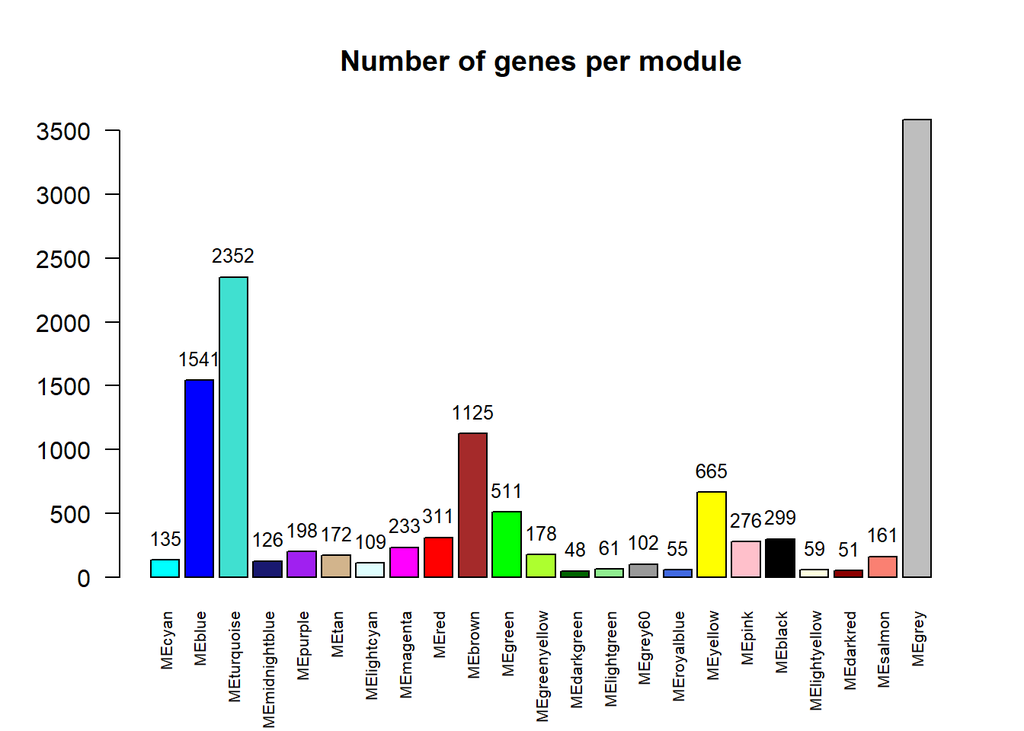

```r
# Number of genes per module
mod_genes = c()
for (i in 1:ncol(modules$MEs)) {
  mod_genes[i] <- sum(paste("ME", modules$colors, sep = "") == colnames(modules$MEs)[i])
}
names(mod_genes) <- colnames(modules$MEs)
xx <- barplot(mod_genes, col = gsub("ME", "", colnames(modules$MEs)),
     main = "Number of genes per module",
     las = 2, cex.names = 0.65,)
text(x = xx, y = mod_genes, label = mod_genes, pos = 3, cex = 0.8)
```

Look at the data returned from blockwiseModules (use str()).

```r
str(modules)
```

```
## List of 10
##  $ colors        : Named chr [1:12353] "grey" "purple" "purple" "yellow" ...
##   ..- attr(*, "names")= chr [1:12353] "ILMN_1660305" "ILMN_1814316" "ILMN_2359168" "ILMN_1731507" ...
##  $ unmergedColors: Named chr [1:12353] "grey" "darkred" "darkred" "green" ...
##   ..- attr(*, "names")= chr [1:12353] "ILMN_1660305" "ILMN_1814316" "ILMN_2359168" "ILMN_1731507" ...
##  $ MEs           :'data.frame':  58 obs. of  23 variables:
##   ..$ MEcyan        : num [1:58] 0.1481 0.0854 -0.0539 0.0942 0.0181 ...
##   ..$ MEblue        : num [1:58] 0.1504 0.1498 -0.0535 0.1362 0.1171 ...
##   ..$ MEturquoise   : num [1:58] 0.1076 0.133 0.0496 0.1122 0.0906 ...
##   ..$ MEmidnightblue: num [1:58] -0.01201 0.04331 0.16348 0.05038 -0.00646 ...
##   ..$ MEpurple      : num [1:58] 0.0916 0.1092 0.0751 0.121 0.0574 ...
##   ..$ MEtan         : num [1:58] 0.0441 0.1375 0.1184 0.1572 0.0992 ...
##   ..$ MElightcyan   : num [1:58] 0.00354 -0.00338 0.06459 0.04283 -0.01264 ...
##   ..$ MEmagenta     : num [1:58] -0.0887 -0.0417 0.1752 -0.0643 -0.0347 ...
##   ..$ MEred         : num [1:58] -0.1416 -0.0117 -0.2233 -0.065 -0.029 ...
##   ..$ MEbrown       : num [1:58] -0.0621 -0.0987 -0.1153 0.2984 -0.1296 ...
##   ..$ MEgreen       : num [1:58] -0.0777 -0.0891 0.0377 -0.0557 -0.0512 ...
##   ..$ MEgreenyellow : num [1:58] -0.1295 -0.1265 -0.0165 -0.06 -0.0618 ...
##   ..$ MEdarkgreen   : num [1:58] 0.041745 -0.076662 0.000849 -0.12575 -0.075989 ...
##   ..$ MElightgreen  : num [1:58] 0.0342 -0.0189 -0.0514 -0.0253 -0.083 ...
##   ..$ MEgrey60      : num [1:58] -0.0954 -0.0532 0.1095 -0.1536 -0.0151 ...
##   ..$ MEroyalblue   : num [1:58] -0.0952 -0.1268 0.0102 -0.1274 -0.0539 ...
##   ..$ MEyellow      : num [1:58] -0.1518 -0.1234 -0.0821 -0.1659 -0.0765 ...
##   ..$ MEpink        : num [1:58] -0.12749 -0.24193 0.06869 -0.25045 -0.00582 ...
##   ..$ MEblack       : num [1:58] -0.0996 -0.1602 0.1141 -0.1701 -0.0668 ...
##   ..$ MElightyellow : num [1:58] -0.06765 -0.11556 0.00867 -0.17596 -0.03402 ...
##   ..$ MEdarkred     : num [1:58] 0.0831 0.0366 -0.0194 0.013 0.0242 ...
##   ..$ MEsalmon      : num [1:58] 0.03959 -0.0434 0.00383 -0.08382 -0.0299 ...
##   ..$ MEgrey        : num [1:58] -0.1053 -0.0251 0.1763 -0.1311 0.0186 ...
##  $ goodSamples   : logi [1:58] TRUE TRUE TRUE TRUE TRUE TRUE ...
##  $ goodGenes     : logi [1:12353] TRUE TRUE TRUE TRUE TRUE TRUE ...
##  $ dendrograms   :List of 3
##   ..$ :List of 7
##   .. ..$ merge      : int [1:4997, 1:2] -1939 -3996 -1362 -452 -532 -4945 -1112 -1857 -3816 -2003 ...
##   .. ..$ height     : num [1:4997] 0.627 0.672 0.675 0.69 0.699 ...
##   .. ..$ order      : int [1:4998] 438 4776 4644 1083 768 4349 3404 148 1604 3525 ...
##   .. ..$ labels     : NULL
##   .. ..$ method     : chr "average"
##   .. ..$ call       : language fastcluster::hclust(d = as.dist(dissTom), method = "average")
##   .. ..$ dist.method: NULL
```

[output cut: 11 more lines]

```
##   .. ..$ merge      : int [1:3511, 1:2] -1318 -786 -1863 -2326 -1502 -3087 -1348 -2184 -1565 -1501 ...
##   .. ..$ height     : num [1:3511] 0.397 0.457 0.532 0.583 0.637 ...
##   .. ..$ order      : int [1:3512] 1703 2198 338 47 1771 2964 2043 2235 2367 571 ...
##   .. ..$ labels     : NULL
##   .. ..$ method     : chr "average"
##   .. ..$ call       : language fastcluster::hclust(d = as.dist(dissTom), method = "average")
##   .. ..$ dist.method: NULL
##   .. ..- attr(*, "class")= chr "hclust"
##  $ TOMFiles      : NULL
##  $ blockGenes    :List of 3
##   ..$ : int [1:4998] 2 3 4 6 14 15 16 19 20 23 ...
##   ..$ : int [1:3843] 7 9 17 18 21 22 25 27 29 33 ...
##   ..$ : int [1:3512] 1 5 8 10 11 12 13 24 26 31 ...
##  $ blocks        : num [1:12353] 3 1 1 1 3 1 2 3 2 3 ...
##  $ MEsOK         : logi TRUE
```

*How do you get the module eigengenes (MEs) and how many are there?* There are 23 module eigengenes with 58 values each. They are located in a dataframe calle MEs in modules, so in order to retrieve it one would have to use modules$ME *Can you get the eigengene vector for the “magenta” ME?*

```r
modules$MEs["MEmagenta"]
```

```
##                 MEmagenta
## 4936551012_A -0.088742759
## 4936551012_B -0.041739335
## 4936551012_D  0.175189742
## 4936551012_H -0.064326037
## 4936551003_A -0.034651914
## 4936551003_B -0.035471144
## 4936551003_D  0.053028451
## 4936551003_E  0.101697679
## 4936551011_A  0.238606920
## 4936551011_B  0.205255351
## 4936551011_G -0.056136897
## 4936551011_H -0.068781162
## 4936551002_D -0.039911240
## 4936551013_A -0.047346833
## 4936551013_D -0.118889809
## 4936551013_E -0.088748128
## 4936551013_G  0.058693855
## 4936551008_A -0.190869989
## 4936551008_B -0.282186924
## 4936551008_H -0.100333285
## 4936551010_D -0.007279010
## 4936551010_G -0.165628613
## 4936551010_H -0.024879174
## 4936551005_A  0.011851826
## 4936551005_B -0.069178003
## 4936551005_D -0.059578041
## 4936551005_E  0.052927930
## 4936551005_H -0.016265142
## 4936551031_A -0.138664646
## 4936551031_B -0.238188568
## 4936551031_D  0.028066819
## 4936551031_E  0.045126867
## 4936551031_H  0.268440884
## 4936551007_A -0.157917798
## 4936551007_B -0.115263436
## 4936551007_D -0.140810669
## 4936551007_E -0.080547504
## 4936551007_G  0.241583213
## 4936551006_A -0.177786652
## 4936551006_D  0.094115614
## 4936551006_E  0.169245930
## 4936551006_G  0.157949837
## 4936551015_A  0.141865531
## 4936551015_B  0.122194521
## 4936551015_D  0.043919617
## 4936551015_E  0.133340934
## 4936551015_G -0.196003006
## 4936551015_H  0.130822778
## 4936551004_A -0.070556929
## 4936551004_B -0.076634074
## 4936551004_D -0.072601723
## 4936551004_E -0.065209506
## 4936551004_H -0.044646249
## 4936551014_A  0.100110431
## 4936551014_B  0.173125915
## 4936551014_D  0.180674719
## 4936551014_E  0.254513581
## 4936551014_G -0.006574747
```

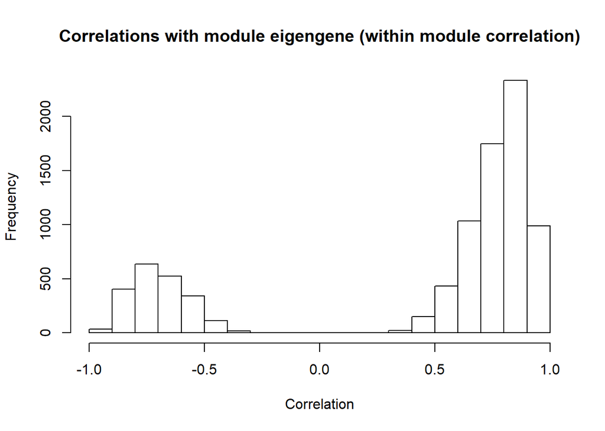

```r
# Compute correlation between all genes and all module eigengenes
kME <- cor(exp, modules$MEs)

# Correlation within modules
intra_cor <- c()
for (m in colnames(kME)) {
  if (m != "MEgrey") {
    intra_cor <- c(intra_cor, kME[paste("ME", modules$colors, sep = "") == m, m])
  }
}
hist(intra_cor, xlim = c(-1,1), breaks = seq(-1,1,0.1),
     main = "Correlations with module eigengene (within module correlation)",
     xlab = "Correlation")
```

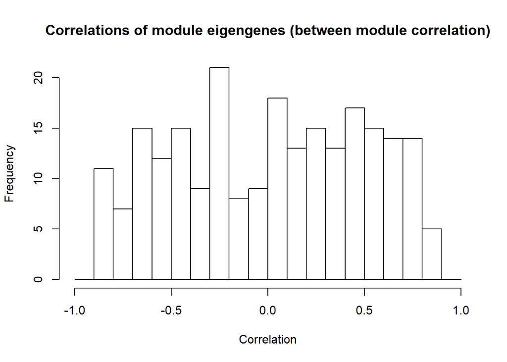

```r
# Correlation between modules
idx <- which(colnames(modules$MEs) == "MEgrey")
MEs_R <- cor(modules$MEs[,-idx], modules$MEs[,-idx])
hist(MEs_R[upper.tri(MEs_R)], xlim = c(-1,1), breaks = seq(-1,1,0.1),
     main = "Correlations of module eigengenes (between module correlation)",
     xlab = "Correlation")
```